# **Informe Técnico: Predicción de la accidentalidad vial de la cuidad de Medellín**

Alexis A. Arenas Bustamante, Juan E. Arroyave Duque, William A. Jovel Tamayo, Manuela Londoño Ocampo.* Curso de Analítica Predictiva Universidad Nacional de Colombia Facultad de Minas Medellín

Septiembre de 2019

# 1 **Introducción**

En el siguiente Notebook se encuentran los análisis y pasos realizados en la construcción de modelos predictivos para la accidentalidad vial dentro de la ciudad de Medellín. Los modelos presentados estarán divididos según la temporalidad de predicción y la gravedad del accidente.

Los datos usado corresponden a **datos abiertos de Medellín** disponibles en el sitio web MEDATA. Se toman como datos de entrenamiento los registros de accidentalidad ocurridos entre el año 2014 y 2018.

Con las técnicas de predicción y agrupamiento aplicadas se busca:

1. Predecir la accidentalidad vial por tipo de accidente
2. Agrupar los barrio de medellín, según su accidentalidad.

El informe técnico resumirá cada uno de los análisis aplicados, en cada sesión del Notebook se encontraran enlaces a recursos mas específicos, según corresponda.

# 2 **Pre procesamiento de los datos**

Primero se aplicaron algunas tareas de integración y posteriormente de limpieza sobre los datos obtenidos del portal de [MEDATA](http://medata.gov.co/dataset/accidentalidad). La base de datos usada es el resultado de consolidar cada una de las bases de datos anuales a la que se tuvo acceso, en una sola base de datos.

|  | X | Y | OBJECTID | RADICADO | FECHA | HORA | DIA | PERIODO | CLASE | DIRECCION | DIRECCION_ENC | CBML | TIPO_GEOCOD | GRAVEDAD | BARRIO | COMUNA | DISENO | DIA_NOMBRE | MES | MES_NOMBRE | X_MAGNAMED | Y_MAGNAMED | LONGITUD | LATITUD |
| --- | --- | --- | --- | --- | --- | --- | --- | --- | --- | --- | --- | --- | --- | --- | --- | --- | --- | --- | --- | --- | --- | --- | --- | --- |
| 1 | -75.60273 | 6.219016 | 211279 | 1423828 | 2014/01/01 00:00:00+00 | 2:20:00 | 1 | 2014 | Choque | CR 80 CL 8 | CR 080 008 000 00000 | 1611 | Malla vial aproximada: CR 81-7 | HERIDO | Loma de los Bernal | Belén | Tramo de via | MIÉRCOLES | 1 | NA | 831190.1 | 1179690 | -75.60273 | 6.219016 |
| 2 | -75.56818 | 6.260009 | 211280 | 1423839 | 2014/01/01 00:00:00+00 | 12:50:00 | 1 | 2014 | Atropello | CR 53 CL 61 | CR 053 061 000 00000 | 1003 | Malla vial | HERIDO | Jesús Nazareno | La Candelaria | Tramo de via | MIÉRCOLES | 1 | NA | 835013.6 | 1184224 | -75.56818 | 6.260009 |
| 3 | -75.54994 | 6.264765 | 211281 | 1423840 | 2014/01/01 00:00:00+00 | 1:00:00 | 1 | 2014 | Atropello | CR 39 CL 70 | CR 039 070 000 00000 | 308 | Malla vial | HERIDO | Manrique Oriental | Manrique | Tramo de via | MIÉRCOLES | 1 | NA | 837032.7 | 1184750 | -75.54994 | 6.264765 |
| 4 | -75.60761 | 6.234327 | 211282 | 1423849 | 2014/01/01 00:00:00+00 | 12:37:00 | 1 | 2014 | Atropello | CL 32 CR 84 | CL 032 084 000 00000 | 1617 | Malla vial | HERIDO | Las Mercedes | Belén | Tramo de via | MIÉRCOLES | 1 | NA | 830649.5 | 1181383 | -75.60761 | 6.234327 |
| 5 | -75.57969 | 6.299968 | 211283 | 1423890 | 2014/01/01 00:00:00+00 | 10:40:00 | 1 | 2014 | Caída de Ocupante | CR 80 CL 101 | CR 080 101 000 00000 | 603 | Malla vial | HERIDO | Doce de Octubre No.2 | Doce de Octubre | Tramo de via | MIÉRCOLES | 1 | NA | 833740.8 | 1188644 | -75.57969 | 6.299968 |
| 6 | -75.55543 | 6.284499 | 211284 | 1423892 | 2014/01/01 00:00:00+00 | 4:00:00 | 1 | 2014 | Choque | CR 48 CL 93 | CR 048 093 000 00000 | 401 | Malla vial | HERIDO | Berlin | Aranjuez | Interseccion | MIÉRCOLES | 1 | NA | 836425.4 | 1186933 | -75.55543 | 6.284499 |

Inicialmente se contaba con 228693 filas y 24 columnas, después del análisis de cada una, se opta por eliminar 9 columnas que presentaban datos muy similares (constantes) o no aportaban datos relevantes para el presente trabajo. Una vez definidas las variables de interés, se procede a evaluar si alguna de estas variables tiene datos ausentes.

```r
dataset_original  <- dplyr :: select(dataset_original, -OBJECTID,-X, -Y, -DIRECCION_ENC,
                                     -DIRECCION, -CBML, -TIPO_GEOCOD, -X_MAGNAMED, -Y_MAGNAMED)

summary(dataset_original)
```

```
##     RADICADO                            FECHA             HORA
##  Min.   :0.000e+00   2017/08/04 00:00:00+00:   231   7:00:00:  6620
##  1st Qu.:1.482e+06   2016/04/08 00:00:00+00:   209   8:00:00:  6392
##  Median :1.540e+06   2015/08/28 00:00:00+00:   200   6:00:00:  5880
##  Mean   :8.399e+15   2015/08/18 00:00:00+00:   195   6:30:00:  5478
##  3rd Qu.:1.598e+06   2016/10/07 00:00:00+00:   193   7:30:00:  5431
##  Max.   :5.002e+20   2016/02/17 00:00:00+00:   190   9:00:00:  5107
##  NA's   :5           (Other)               :227475   (Other):193785
##       DIA          PERIODO                   CLASE              GRAVEDAD
##  Min.   : 1.0   Min.   :2014   Choque           :152433   HERIDO    :126222
##  1st Qu.: 8.0   1st Qu.:2015   Otro             : 25173   MUERTO    :  1374
##  Median :16.0   Median :2016   Atropello        : 22210   SOLO DAÑOS:101097
##  Mean   :15.7   Mean   :2016   Caida Ocupante   : 14602
##  3rd Qu.:23.0   3rd Qu.:2017   Volcamiento      :  7722
##  Max.   :31.0   Max.   :2018   Caída de Ocupante:  6496
##                                (Other)          :    57
##                 BARRIO                    COMUNA                DISENO
##  0                 : 13889   La Candelaria   :44148   Tramo de via :166952
##  La Candelaria     :  5101   Laureles Estadio:24029   Interseccion : 34819
##  Caribe            :  4461   Castilla        :21532   Lote o Predio: 16841
##  Campo Amor        :  4231   El Poblado      :18733   Glorieta     :  5431
##  Perpetuo Socorro  :  4142   Guayabal        :15840                :  1284
##  Los Conquistadores:  3765   Belén           :14402   Paso Elevado :  1074
##  (Other)           :193104   (Other)         :90009   (Other)      :  2292
##      DIA_NOMBRE         MES         MES_NOMBRE        LONGITUD
##  DOMINGO  :22210   Min.   : 1.000   Mode:logical   Min.   :-75.70
##  JUEVES   :34221   1st Qu.: 4.000   NA's:228693    1st Qu.:-75.59
##  LUNES    :32778   Median : 7.000                  Median :-75.58
##  MARTES   :35390   Mean   : 6.575                  Mean   :-75.59
##  MIÉRCOLES:34970   3rd Qu.: 9.000                  3rd Qu.:-75.57
##  SÁBADO   :32826   Max.   :12.000                  Max.   :-75.47
##  VIERNES  :36298
##     LATITUD
##  Min.   :6.152
##  1st Qu.:6.226
##  Median :6.248
##  Mean   :6.248
##  3rd Qu.:6.268
##  Max.   :6.343
##
```

## 2.1 **Tratamiento de Missing**

| Variable | Faltantes |
| --- | --- |
| CBML | 8.64% |
| BARRIO | 8,64% |
| COMUNA | 8.63% |

En el **summary** anterior se pueden observar algunos valores en 0 en la columna Barrio, estos son indicios de que el data set presenta columnas con datos ausentes. Al analizar independiente cada columna, se identificó que CBML, BARRIO y COMUNA son aquellas que tienen un porcentaje de datos ausentes mayor.

Dado que los barrios harán parte del agrupamiento propuesto y con el animo de recuperar la mayor cantidad de registros de accidentes, se filtró de esta columna, todos aquellos valores faltantes y que a su vez tenían asociada una dirección. Luego, en la pagina de [Mapas Medellin](https://www.medellin.gov.co/MAPGISV5_WEB/mapa.jsp?aplicacion=0) se cargó un archivo en formato *xlsx* que únicamente tenía cargada la columna con las direcciones; el sitio procesó el documento y devolvió los nombres de los barrios para cada dirección y esta nueva información fue incorporada al archivo base.

|  | RADICADO | FECHA | HORA | DIA | PERIODO | CLASE | GRAVEDAD | BARRIO | COMUNA | DISENO | DIA_NOMBRE | MES | MES_NOMBRE | LONGITUD | LATITUD | TIPO_ACCIDENTE | SEMANA |
| --- | --- | --- | --- | --- | --- | --- | --- | --- | --- | --- | --- | --- | --- | --- | --- | --- | --- |
| 1 | 1423828 | 2014/01/01 | 2:20:00 | 1 | 2014 | Choque | Herido | Loma de los Bernal | Belén | Tramo de via | Miercoles | 1 | Enero | -75.60273 | 6.219016 | Grave | 1 |
| 2 | 1423839 | 2014/01/01 | 12:50:00 | 1 | 2014 | Atropello | Herido | Jesús Nazareno | La Candelaria | Tramo de via | Miercoles | 1 | Enero | -75.56818 | 6.260009 | Grave | 1 |
| 3 | 1423840 | 2014/01/01 | 1:00:00 | 1 | 2014 | Atropello | Herido | Manrique Oriental | Manrique | Tramo de via | Miercoles | 1 | Enero | -75.54994 | 6.264765 | Grave | 1 |
| 4 | 1423849 | 2014/01/01 | 12:37:00 | 1 | 2014 | Atropello | Herido | Las Mercedes | Belén | Tramo de via | Miercoles | 1 | Enero | -75.60761 | 6.234327 | Grave | 1 |
| 5 | 1423890 | 2014/01/01 | 10:40:00 | 1 | 2014 | Caida de Ocupante | Herido | Doce de Octubre No.2 | Doce de Octubre | Tramo de via | Miercoles | 1 | Enero | -75.57969 | 6.299968 | Grave | 1 |
| 6 | 1423892 | 2014/01/01 | 4:00:00 | 1 | 2014 | Choque | Herido | Berlin | Aranjuez | Interseccion | Miercoles | 1 | Enero | -75.55543 | 6.284499 | Grave | 1 |

Los barrios con registro pasaron de 208,868 a 214,797. Los registros que no pudieron recuperarse fueron eliminados del análisis, así como algunos en los su nomenclatura indicaban un error. Para las columna de diseño y clase, cuyos valores nulos no superaban los 200 registros, se opto por la imputación usando la moda. También se identificó datos erróneos en los barrios y comunas, dichos datos fueron descartados, dado que representan información no confiable.

Se creó la variable derivada semana para completar la temporalidad a la que se debe tener acceso para los modelo predictivos que se modelarán posteriormente. El dataset final después de la limpieza y homologan de datos, esta compuesto por 214566 filas y 17 Columnas.

# 3 **Análisis Descriptivo**

Para la predicción se definieron 3 tipo de accidentes a modelar: - accidentes con solo daños - accidentes con heridos - accidentes con muertos.

## 3.1 **Tipos de accidente**

Como se puede observar existen 3 clases de accidentes que indican el nivel de gravedad del evento. La mayoría de los accidentes ocurridos en el periodo de tiempo analizado tuvieron heridos y en muy pocos hubo muertos, aquí se observa un desbalanceo de clases que puede influir en los resultados de los modelos propuestos, dado que para el caso de los accidentes con muertos, las datos disponibles son muy pocos en comparación con los otros tipo de accidentes y esto dificulta el entrenamiento de los mismos.

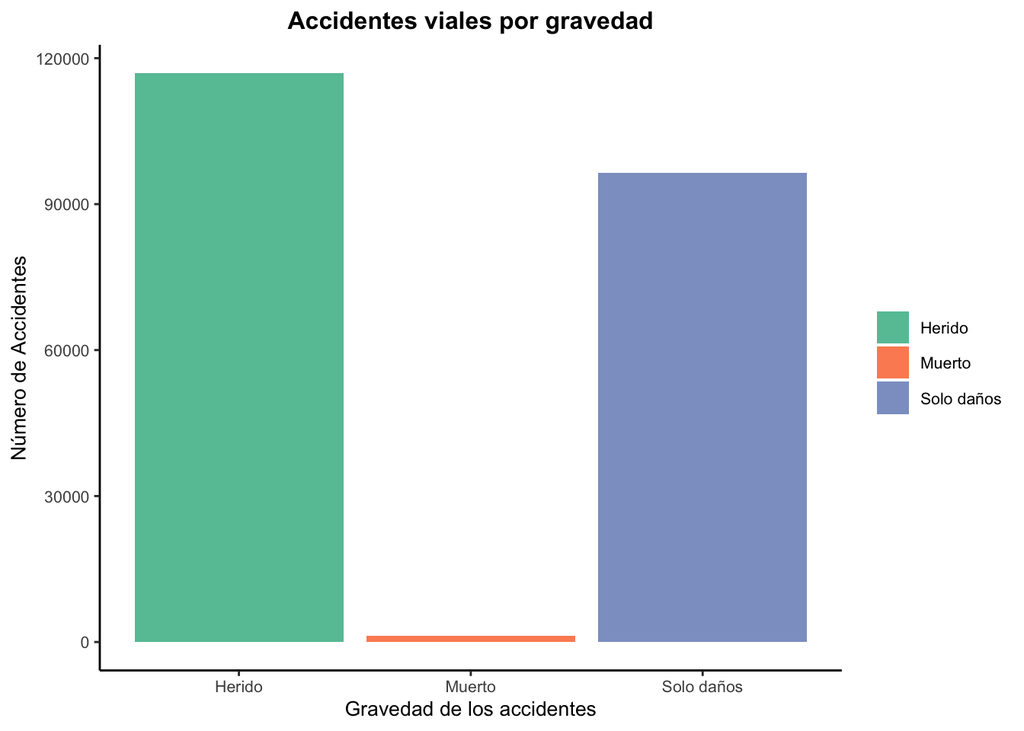

## 3.2 **Accidentes por Año**

En el año 2016 se presentaron mas accidentes viales en la cuidad de medellin en comparación con los demás años. Aunque la variación entre periodo no es muy amplia, en la siguiente gráfica se puede observar que la tendencia empieza a decrecer a partir del año 2017 de manera leve. Esto hace que no se tenga un patrón de tendencia muy marcado, lo que podría influir en que los modelos presenten problemas de sobre-entrenamiento, puesto que la validación se realizará con los datos disponibles para el año 2018.

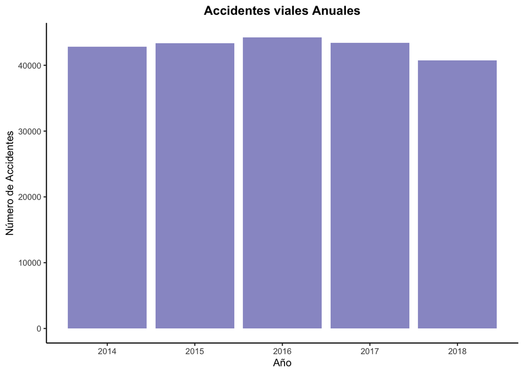

## 3.3 **Accidentes por mes**

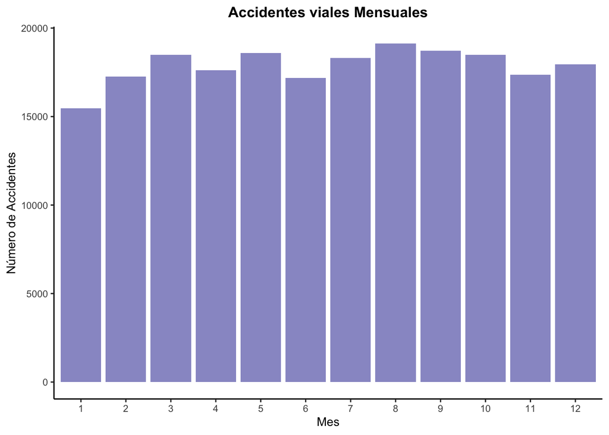

También se observa que hay picos de accidentes en los meses marzo, mayo y agosto. Se cree que estas variables serán significativas para los modelos propuestos.

## 3.4 **Accidentes por Semana**

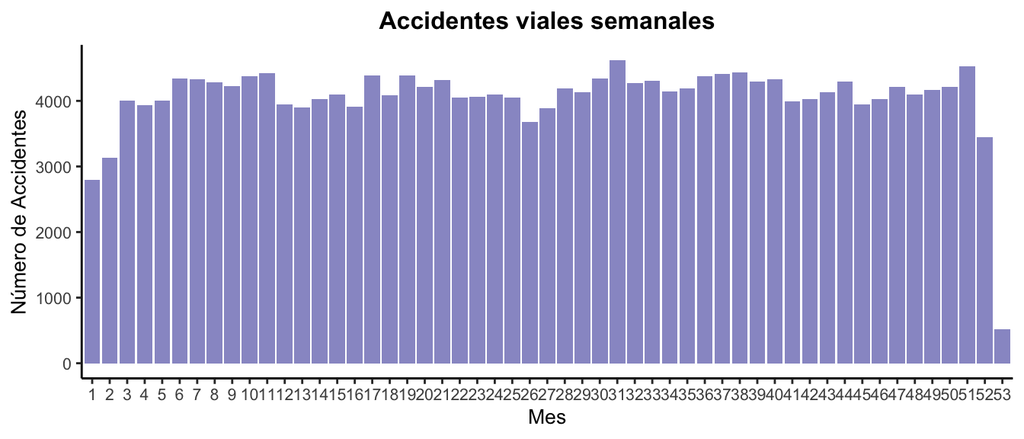

Aquí se puede observar de manera mas granular la ocurrencia de accidentes viales en la cuidad de medellin. Es destacable que algunas variables tienen decrecimientos en la cantidad de accidentes y su influencia sobre la variable dependiente, que en este caso es al cantidad de accidentes ocurridos, puede ser significativa; lo mismo puede suceder con las semanas donde se alcancen picos altos de accidentalidad.

## 3.5 **Inclusión de variables: Fechas especiales / festivos**

Se introdujeron al análisis diferentes variables indicadoras relacionadas con días festivos, eventos de importante concurrencia en la cuidad y fechas especiales. Entre las principales variables adicionadas se presentan tres:

**FESTIVOS** : Indica si un día es festivo (FESTIVO = 1) o no (FESTIVO = 0).

**SEMANA_SANTA** : Indica si el día se encuentra en la semana en que se celebra semana santa en Colombia (SEMANA_SANTA = 1) o no (SEMANA_SANTA = 0).

**FERIA_FLORES**: Indica si el día se encuentra en la semana en que se celebra feria de flores en Medellín (FERIA_FLORES = 1) o no (FERIA_FLORES = 0).

### 3.5.1 **Accidentes en días festivos**

Se puede observar que la cantidad de accidentes es mayor para los días que no son festivos dado que su distribución es mayor, por su parte los días festivos presentan una media menor.

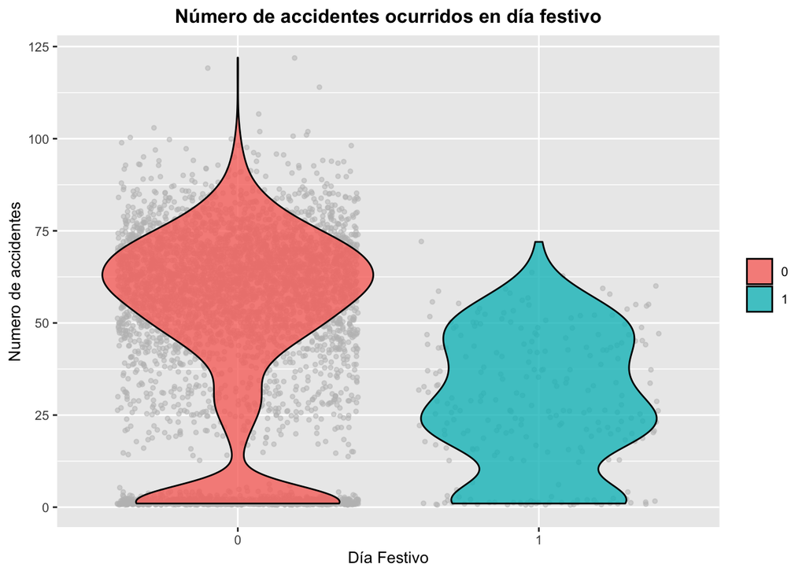

### 3.5.2 **Accidentes en Semana Santa**

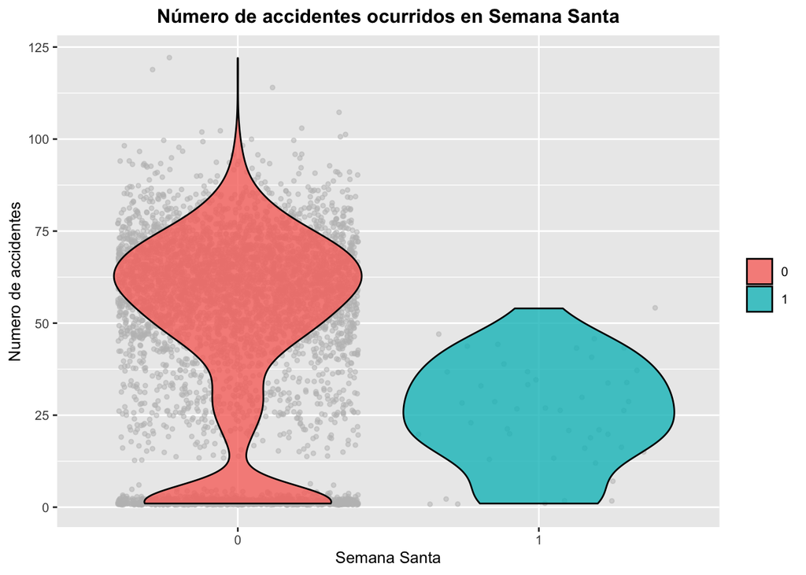

De manera similar es posible afirmar que la cantidad de accidentes ocurridos en Semana Santa es menor en comparación con los demás días del año.

### 3.5.3 **Accidentes en Feria de Flores**

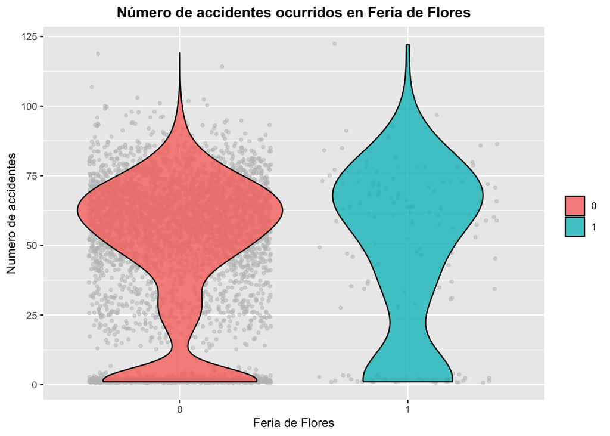

Para los días en los que se celebra feria de flores, podemos observar que su distribución es mayor en comparación con las variables anteriormente expuestas. Estos días de mayor actividad en la cuidad pueden influir en que la tasa de accidentalidad para el mes de agosto sea mayor que la de otros meses.

# 4 **Preparación de conjuntos de datos**

Como se explico anteriormente, se pretende modelar la accidentalidad vial de la cuidad de Medellín por tipo de gravedad de manera mensual, semanal y diaria. En total se proponen nueve modelos.

Para cada uno de ellos se evaluó la relevancia de las variables incluidas, considerando la precisión obtenida en el proceso de validación cruzada. Para cada modelo se presentan las variables usadas en el proceso de moderación:

## 4.1 **Modelos Mensuales**

### 4.1.1 **Dataset del modelo mensual: Solo daños**

```
##     PERIODO          MES             SEMANA         FESTIVOS
##  Min.   :2014   Min.   : 1.000   Min.   : 1.00   Min.   :0.0000
##  1st Qu.:2015   1st Qu.: 4.000   1st Qu.:14.00   1st Qu.:0.0000
##  Median :2016   Median : 7.000   Median :26.00   Median :0.0000
##  Mean   :2016   Mean   : 6.618   Mean   :26.93   Mean   :0.2136
##  3rd Qu.:2017   3rd Qu.:10.000   3rd Qu.:40.75   3rd Qu.:0.0000
##  Max.   :2018   Max.   :12.000   Max.   :53.00   Max.   :1.0000
##   SOLO_DANOS.R
##  Min.   :  6.00
##  1st Qu.: 66.25
##  Median :303.00
##  Mean   :246.65
##  3rd Qu.:375.00
##  Max.   :477.00
```

Para la predicción mensual de accidentes viales con solo daños, se consideraron las variables:

- PERIODO: Variable que indica el año en que ocurren los accidente, esta variable se usó para la separación de datos en el proceso de validación cruzada. No hace parte del modelo predictivo.
- MES: Variable que indica el mes en que ocurren los accidentes, puede tomar valores entre 1 y 12.
- SEMANA: Variable que indica la semana del año en que ocurren los accidentes, puede tomar valores entre 1 y 53.
- FESTIVO: Indica si en el mes existen días festivos o no.

### 4.1.2 **Dataset del modelo mensual: Heridos**

```
##     PERIODO          MES             SEMANA         FESTIVOS
##  Min.   :2014   Min.   : 1.000   Min.   : 1.00   Min.   :0.0000
##  1st Qu.:2015   1st Qu.: 4.000   1st Qu.:14.00   1st Qu.:0.0000
##  Median :2016   Median : 7.000   Median :26.00   Median :0.0000
##  Mean   :2016   Mean   : 6.618   Mean   :26.93   Mean   :0.2136
##  3rd Qu.:2017   3rd Qu.:10.000   3rd Qu.:40.75   3rd Qu.:0.0000
##  Max.   :2018   Max.   :12.000   Max.   :53.00   Max.   :1.0000
##    HERIDOS.R
##  Min.   : 26.0
##  1st Qu.:113.2
##  Median :352.0
##  Mean   :299.1
##  3rd Qu.:454.8
##  Max.   :545.0
```

Para la predicción mensual de accidentes viales con heridos, se consideraron las variables:

- PERIODO: Variable que indica el año en que ocurren los accidente, esta variable se usó para la separación de datos en el proceso de validación cruzada. No hace parte del modelo predictivo.
- MES: Variable que indica el mes en que ocurren los accidentes, puede tomar valores entre 1 y 12.
- SEMANA: Variable que indica la semana del año en que ocurren los accidentes, puede tomar valores entre 1 y 53.
- FESTIVO: Indica si en el mes existen días festivos o no.

### 4.1.3 **Dataset del modelo mensual: Muertos**

```
##     PERIODO          MES             SEMANA         FESTIVOS
##  Min.   :2014   Min.   : 1.000   Min.   : 1.00   Min.   :0.0000
##  1st Qu.:2015   1st Qu.: 4.000   1st Qu.:14.00   1st Qu.:0.0000
##  Median :2016   Median : 7.000   Median :26.00   Median :0.0000
##  Mean   :2016   Mean   : 6.618   Mean   :26.93   Mean   :0.2136
##  3rd Qu.:2017   3rd Qu.:10.000   3rd Qu.:40.75   3rd Qu.:0.0000
##  Max.   :2018   Max.   :12.000   Max.   :53.00   Max.   :1.0000
##    MUERTES.R
##  Min.   : 0.000
##  1st Qu.: 1.000
##  Median : 3.000
##  Mean   : 3.064
##  3rd Qu.: 5.000
##  Max.   :11.000
```

Para la predicción mensual de accidentes viales con muertos, se consideraron las variables:

- PERIODO: Variable que indica el año en que ocurren los accidente, esta variable se usó para la separación de datos en el proceso de validación cruzada. No hace parte del modelo predictivo.
- MES: Variable que indica el mes en que ocurren los accidentes, puede tomar valores entre 1 y 12.
- SEMANA: Variable que indica la semana del año en que ocurren los accidentes, puede tomar valores entre 1 y 53.
- FESTIVO: Indica si en el mes existen días festivos o no.

## 4.2 **Modelos Semanales**

### 4.2.1 **Dataset del modelo semanal: Solo daños**

```
##    SOLO_DANOS         ANYO           SEMANA         FESTIVOS
##  Min.   :  6.0   Min.   :1.000   Min.   : 1.00   Min.   :0.0000
##  1st Qu.: 42.0   1st Qu.:2.000   1st Qu.:15.00   1st Qu.:0.0000
##  Median :332.0   Median :3.000   Median :28.00   Median :0.0000
##  Mean   :255.7   Mean   :2.992   Mean   :27.34   Mean   :0.2308
##  3rd Qu.:383.0   3rd Qu.:4.000   3rd Qu.:41.00   3rd Qu.:0.0000
##  Max.   :477.0   Max.   :5.000   Max.   :53.00   Max.   :1.0000
##   SEMANA_SANTA      COLOMBIAMODA      FERIA_FLORES        ENERO_1
##  Min.   :0.00000   Min.   :0.00000   Min.   :0.00000   Min.   :0.00000
##  1st Qu.:0.00000   1st Qu.:0.00000   1st Qu.:0.00000   1st Qu.:0.00000
##  Median :0.00000   Median :0.00000   Median :0.00000   Median :0.00000
##  Mean   :0.03183   Mean   :0.01857   Mean   :0.03714   Mean   :0.01326
##  3rd Qu.:0.00000   3rd Qu.:0.00000   3rd Qu.:0.00000   3rd Qu.:0.00000
##  Max.   :1.00000   Max.   :1.00000   Max.   :1.00000   Max.   :1.00000
##   PUENTE_REYES         DIC_31            DIC_24
##  Min.   :0.00000   Min.   :0.00000   Min.   :0.00000
##  1st Qu.:0.00000   1st Qu.:0.00000   1st Qu.:0.00000
##  Median :0.00000   Median :0.00000   Median :0.00000
##  Mean   :0.01326   Mean   :0.01326   Mean   :0.01326
##  3rd Qu.:0.00000   3rd Qu.:0.00000   3rd Qu.:0.00000
##  Max.   :1.00000   Max.   :1.00000   Max.   :1.00000
```

Para la predicción semanal de accidentes viales con solo daños, se consideraron las variables:

- ANYO: Variable que indica el año en que ocurren los accidente, esta variable se usó para la separación de datos en el proceso de validación cruzada. No hace parte del modelo predictivo.
- SEMANA: Variable que indica la semana del año en que ocurren los accidentes, puede tomar valores entre 1 y 53.
- FESTIVO: Indica si en el mes existen días festivos o no. Toma valores entre 0 y 1.

-SEMANA SANTA: Indica si es la semana en que se celebra semana santa. Toma valores entre 0 y 1.

- COLOMBIAMODA: Indica si es la semana en que tiene lugar el evento de Colombia Moda. Toma valores entre 0 y 1.
- FERIA DE FLORES: Indica si es la semana en que se celebra feria de flores. Toma valores entre 0 y 1.
- ENERO_1: Indica si en la semana se encuentra el día primero de enero. Toma valores entre 0 y 1.
- PUENTE_REYES: Indica si es la semana en que tiene lugar el conocido puente de reyes. Toma valores entre 0 y 1.
- DIC_24: Indica si en la semana se encuentra el día 24 de diciembre. Toma valores entre 0 y 1.
- DIC_31: Indica si en la semana se encuentra el día 31 de diciembre. Toma valores entre 0 y 1.

### 4.2.2 **Dataset del modelo semanal: Heridos**

```
##     HERIDOS           ANYO           SEMANA         FESTIVOS
##  Min.   : 26.0   Min.   :1.000   Min.   : 1.00   Min.   :0.0000
##  1st Qu.: 66.0   1st Qu.:2.000   1st Qu.:15.00   1st Qu.:0.0000
##  Median :391.0   Median :3.000   Median :28.00   Median :0.0000
##  Mean   :310.1   Mean   :2.992   Mean   :27.34   Mean   :0.2308
##  3rd Qu.:460.0   3rd Qu.:4.000   3rd Qu.:41.00   3rd Qu.:0.0000
##  Max.   :545.0   Max.   :5.000   Max.   :53.00   Max.   :1.0000
##   SEMANA_SANTA      COLOMBIAMODA      FERIA_FLORES        ENERO_1
##  Min.   :0.00000   Min.   :0.00000   Min.   :0.00000   Min.   :0.00000
##  1st Qu.:0.00000   1st Qu.:0.00000   1st Qu.:0.00000   1st Qu.:0.00000
##  Median :0.00000   Median :0.00000   Median :0.00000   Median :0.00000
##  Mean   :0.03183   Mean   :0.01857   Mean   :0.03714   Mean   :0.01326
##  3rd Qu.:0.00000   3rd Qu.:0.00000   3rd Qu.:0.00000   3rd Qu.:0.00000
##  Max.   :1.00000   Max.   :1.00000   Max.   :1.00000   Max.   :1.00000
##   PUENTE_REYES         DIC_31            DIC_24
##  Min.   :0.00000   Min.   :0.00000   Min.   :0.00000
##  1st Qu.:0.00000   1st Qu.:0.00000   1st Qu.:0.00000
##  Median :0.00000   Median :0.00000   Median :0.00000
##  Mean   :0.01326   Mean   :0.01326   Mean   :0.01326
##  3rd Qu.:0.00000   3rd Qu.:0.00000   3rd Qu.:0.00000
##  Max.   :1.00000   Max.   :1.00000   Max.   :1.00000
```

- ANYO: Variable que indica el año en que ocurren los accidente, esta variable se usó para la separación de datos en el proceso de validación cruzada. No hace parte del modelo predictivo.
- SEMANA: Variable que indica la semana del año en que ocurren los accidentes, puede tomar valores entre 1 y 53.
- FESTIVO: Indica si en el mes existen días festivos o no. Toma valores entre 0 y 1.

-SEMANA SANTA: Indica si es la semana en que se celebra semana santa. Toma valores entre 0 y 1.

- COLOMBIAMODA: Indica si es la semana en que tiene lugar el evento de Colombia Moda. Toma valores entre 0 y 1.
- FERIA DE FLORES: Indica si es la semana en que se celebra feria de flores. Toma valores entre 0 y 1.
- ENERO_1: Indica si en la semana se encuentra el día primero de enero. Toma valores entre 0 y 1.
- PUENTE_REYES: Indica si es la semana en que tiene lugar el conocido puente de reyes. Toma valores entre 0 y 1.
- DIC_24: Indica si en la semana se encuentra el día 24 de diciembre. Toma valores entre 0 y 1.
- DIC_31: Indica si en la semana se encuentra el día 31 de diciembre. Toma valores entre 0 y 1.

### 4.2.3 **Dataset del modelo semanal: Muertos**

```
##     MUERTES            ANYO           SEMANA         FESTIVOS
##  Min.   : 0.000   Min.   :1.000   Min.   : 1.00   Min.   :0.0000
##  1st Qu.: 1.000   1st Qu.:2.000   1st Qu.:15.00   1st Qu.:0.0000
##  Median : 3.000   Median :3.000   Median :28.00   Median :0.0000
##  Mean   : 3.332   Mean   :2.992   Mean   :27.34   Mean   :0.2308
##  3rd Qu.: 5.000   3rd Qu.:4.000   3rd Qu.:41.00   3rd Qu.:0.0000
##  Max.   :14.000   Max.   :5.000   Max.   :53.00   Max.   :1.0000
##   SEMANA_SANTA      COLOMBIAMODA      FERIA_FLORES        ENERO_1
##  Min.   :0.00000   Min.   :0.00000   Min.   :0.00000   Min.   :0.00000
##  1st Qu.:0.00000   1st Qu.:0.00000   1st Qu.:0.00000   1st Qu.:0.00000
##  Median :0.00000   Median :0.00000   Median :0.00000   Median :0.00000
##  Mean   :0.03183   Mean   :0.01857   Mean   :0.03714   Mean   :0.01326
##  3rd Qu.:0.00000   3rd Qu.:0.00000   3rd Qu.:0.00000   3rd Qu.:0.00000
##  Max.   :1.00000   Max.   :1.00000   Max.   :1.00000   Max.   :1.00000
##   PUENTE_REYES         DIC_31            DIC_24
##  Min.   :0.00000   Min.   :0.00000   Min.   :0.00000
##  1st Qu.:0.00000   1st Qu.:0.00000   1st Qu.:0.00000
##  Median :0.00000   Median :0.00000   Median :0.00000
##  Mean   :0.01326   Mean   :0.01326   Mean   :0.01326
##  3rd Qu.:0.00000   3rd Qu.:0.00000   3rd Qu.:0.00000
##  Max.   :1.00000   Max.   :1.00000   Max.   :1.00000
```

- PERIODO: Variable que indica el año en que ocurren los accidente, esta variable se usó para la separación de datos en el proceso de validación cruzada. No hace parte del modelo predictivo.
- SEMANA: Variable que indica la semana del año en que ocurren los accidentes, puede tomar valores entre 1 y 53.
- FESTIVO: Indica si en el mes existen días festivos o no. Toma valores entre 0 y 1.

-SEMANA SANTA: Indica si es la semana en que se celebra semana santa. Toma valores entre 0 y 1.

- COLOMBIAMODA: Indica si es la semana en que tiene lugar el evento de Colombia Moda. Toma valores entre 0 y 1.
- FERIA DE FLORES: Indica si es la semana en que se celebra feria de flores. Toma valores entre 0 y 1.
- ENERO_1: Indica si en la semana se encuentra el día primero de enero. Toma valores entre 0 y 1.
- PUENTE_REYES: Indica si es la semana en que tiene lugar el conocido puente de reyes. Toma valores entre 0 y 1.
- DIC_24: Indica si en la semana se encuentra el día 24 de diciembre. Toma valores entre 0 y 1.
- DIC_31: Indica si en la semana se encuentra el día 31 de diciembre. Toma valores entre 0 y 1.

## 4.3 **Modelos Diarios**

### 4.3.1 **Dataset del modelo diario: Solo daños**

```
##    SOLO_DANOS       ENERO_1          PUENTE_REYES       SEMANA_SANTA
##  Min.   :  5.0   Min.   :0.000000   Min.   :0.000000   Min.   :0.00000
##  1st Qu.: 43.0   1st Qu.:0.000000   1st Qu.:0.000000   1st Qu.:0.00000
##  Median : 56.0   Median :0.000000   Median :0.000000   Median :0.00000
##  Mean   : 52.8   Mean   :0.002738   Mean   :0.002738   Mean   :0.01095
##  3rd Qu.: 65.0   3rd Qu.:0.000000   3rd Qu.:0.000000   3rd Qu.:0.00000
##  Max.   :103.0   Max.   :1.000000   Max.   :1.000000   Max.   :1.00000
##    DIA_MADRES        FERIA_FLORES         DIC_24             DIC_25
##  Min.   :0.000000   Min.   :0.00000   Min.   :0.000000   Min.   :0.000000
##  1st Qu.:0.000000   1st Qu.:0.00000   1st Qu.:0.000000   1st Qu.:0.000000
##  Median :0.000000   Median :0.00000   Median :0.000000   Median :0.000000
##  Mean   :0.002738   Mean   :0.02738   Mean   :0.002738   Mean   :0.002738
##  3rd Qu.:0.000000   3rd Qu.:0.00000   3rd Qu.:0.000000   3rd Qu.:0.000000
##  Max.   :1.000000   Max.   :1.00000   Max.   :1.000000   Max.   :1.000000
##      DIC_31            FESTIVOS           Martes         Miercoles
##  Min.   :0.000000   Min.   :0.00000   Min.   :0.0000   Min.   :0.0000
##  1st Qu.:0.000000   1st Qu.:0.00000   1st Qu.:0.0000   1st Qu.:0.0000
##  Median :0.000000   Median :0.00000   Median :0.0000   Median :0.0000
##  Mean   :0.002738   Mean   :0.05312   Mean   :0.1424   Mean   :0.1429
##  3rd Qu.:0.000000   3rd Qu.:0.00000   3rd Qu.:0.0000   3rd Qu.:0.0000
##  Max.   :1.000000   Max.   :1.00000   Max.   :1.0000   Max.   :1.0000
##      Jueves          Viernes           Sabado          Domingo
##  Min.   :0.0000   Min.   :0.0000   Min.   :0.0000   Min.   :0.0000
##  1st Qu.:0.0000   1st Qu.:0.0000   1st Qu.:0.0000   1st Qu.:0.0000
##  Median :0.0000   Median :0.0000   Median :0.0000   Median :0.0000
##  Mean   :0.1429   Mean   :0.1429   Mean   :0.1429   Mean   :0.1429
##  3rd Qu.:0.0000   3rd Qu.:0.0000   3rd Qu.:0.0000   3rd Qu.:0.0000
##  Max.   :1.0000   Max.   :1.0000   Max.   :1.0000   Max.   :1.0000
```

Para la predicción diaria de accidentes viales con solo daños, se consideraron las variables:

- ENERO_1: Indica si el día es el primero de enero. Sus valores son binarios - 0 y 1.
- PUENTE_REYES: Indica si el día esta dentro del conocido puente de reyes. Sus valores son binarios - 0 y 1.
- SEMANA SANTA: Indica si los días hacen parte de la celebración de semana santa. Sus valores son binarios - 0 y 1.
- DIA_MADRES: Indica si es el día de las madres. Sus valores son binarios - 0 y 1.
- FERIA DE FLORES: Indica si el día esta dentro de la celebración de feria de flores. Sus valores son binarios - 0 y 1.
- DIC_24: Indica si el día es 24 de diciembre. Sus valores son binarios - 0 y 1.
- DIC_25: Indica si el día es 25 de diciembre. Sus valores son binarios - entre 0 y 1.
- DIC_31: Indica si el día es 31 de diciembre. Sus valores son binarios - 0 y 1.
- FESTIVO: Indica si el día es festivo o no. Sus valores son binarios - 0 y 1.
- Días de la semana: Variables dummy que indican el día de la semana (Martes, Miércoles, Jueves, Viernes, Habado y Domingo).

### 4.3.2 **Dataset del modelo diario: Heridos**

```
##     PERIODO       HERIDOS        PUENTE_REYES       SEMANA_SANTA
##  Min.   :1.0   Min.   : 20.00   Min.   :0.000000   Min.   :0.00000
##  1st Qu.:1.0   1st Qu.: 55.25   1st Qu.:0.000000   1st Qu.:0.00000
##  Median :1.0   Median : 64.00   Median :0.000000   Median :0.00000
##  Mean   :1.2   Mean   : 64.02   Mean   :0.002738   Mean   :0.01095
##  3rd Qu.:1.0   3rd Qu.: 73.00   3rd Qu.:0.000000   3rd Qu.:0.00000
##  Max.   :2.0   Max.   :122.00   Max.   :1.000000   Max.   :1.00000
##   COLOMBIAMODA         FESTIVOS           Lunes            Martes
##  Min.   :0.000000   Min.   :0.00000   Min.   :0.0000   Min.   :0.0000
##  1st Qu.:0.000000   1st Qu.:0.00000   1st Qu.:0.0000   1st Qu.:0.0000
##  Median :0.000000   Median :0.00000   Median :0.0000   Median :0.0000
##  Mean   :0.008215   Mean   :0.05312   Mean   :0.1429   Mean   :0.1424
##  3rd Qu.:0.000000   3rd Qu.:0.00000   3rd Qu.:0.0000   3rd Qu.:0.0000
##  Max.   :1.000000   Max.   :1.00000   Max.   :1.0000   Max.   :1.0000
##    Miercoles          Jueves          Viernes           Sabado
##  Min.   :0.0000   Min.   :0.0000   Min.   :0.0000   Min.   :0.0000
##  1st Qu.:0.0000   1st Qu.:0.0000   1st Qu.:0.0000   1st Qu.:0.0000
##  Median :0.0000   Median :0.0000   Median :0.0000   Median :0.0000
##  Mean   :0.1429   Mean   :0.1429   Mean   :0.1429   Mean   :0.1429
##  3rd Qu.:0.0000   3rd Qu.:0.0000   3rd Qu.:0.0000   3rd Qu.:0.0000
##  Max.   :1.0000   Max.   :1.0000   Max.   :1.0000   Max.   :1.0000
```

- PUENTE_REYES: Indica si el día esta dentro del conocido puente de reyes. Sus valores son binarios - 0 y 1.
- SEMANA SANTA: Indica si los días hacen parte de la celebración de semana santa. Sus valores son binarios - 0 y 1.
- COLOMBIAMODA: Indica si es el día esta dentro de la celebración de Colombia Moda. Sus valores son binarios - 0 y 1.
- FESTIVO: Indica si el día es festivo o no. Sus valores son binarios - 0 y 1.
- Días de la semana: Variables dummy que indican el día de la semana (Martes, Miércoles, Jueves, Viernes, Habado).

### 4.3.3 **Dataset del modelo diario: Muertos**

```
##     PERIODO         MUERTOS          DIC_25               H1
##  Min.   :1.000   Min.   :1.000   Min.   :0.000000   Min.   :0.0000
##  1st Qu.:1.000   1st Qu.:1.000   1st Qu.:0.000000   1st Qu.:0.0000
##  Median :1.000   Median :1.000   Median :0.000000   Median :0.0000
##  Mean   :1.192   Mean   :1.483   Mean   :0.003542   Mean   :0.1039
##  3rd Qu.:1.000   3rd Qu.:2.000   3rd Qu.:0.000000   3rd Qu.:0.0000
##  Max.   :2.000   Max.   :6.000   Max.   :1.000000   Max.   :1.0000
##        H2                H3                H4                H5
##  Min.   :0.00000   Min.   :0.00000   Min.   :0.00000   Min.   :0.0000
##  1st Qu.:0.00000   1st Qu.:0.00000   1st Qu.:0.00000   1st Qu.:0.0000
##  Median :0.00000   Median :0.00000   Median :0.00000   Median :0.0000
##  Mean   :0.08501   Mean   :0.09917   Mean   :0.09917   Mean   :0.1181
##  3rd Qu.:0.00000   3rd Qu.:0.00000   3rd Qu.:0.00000   3rd Qu.:0.0000
##  Max.   :1.00000   Max.   :1.00000   Max.   :1.00000   Max.   :1.0000
##        H6               H7               H8               H9
##  Min.   :0.0000   Min.   :0.0000   Min.   :0.0000   Min.   :0.0000
##  1st Qu.:0.0000   1st Qu.:0.0000   1st Qu.:0.0000   1st Qu.:0.0000
##  Median :0.0000   Median :0.0000   Median :0.0000   Median :0.0000
##  Mean   :0.1311   Mean   :0.1346   Mean   :0.1181   Mean   :0.1275
##  3rd Qu.:0.0000   3rd Qu.:0.0000   3rd Qu.:0.0000   3rd Qu.:0.0000
##  Max.   :1.0000   Max.   :1.0000   Max.   :1.0000   Max.   :1.0000
##       H10              H11              H12
##  Min.   :0.0000   Min.   :0.0000   Min.   :0.00000
##  1st Qu.:0.0000   1st Qu.:0.0000   1st Qu.:0.00000
##  Median :0.0000   Median :0.0000   Median :0.00000
##  Mean   :0.1157   Mean   :0.1263   Mean   :0.09799
##  3rd Qu.:0.0000   3rd Qu.:0.0000   3rd Qu.:0.00000
##  Max.   :1.0000   Max.   :1.0000   Max.   :1.00000
```

- DIC_25: Indica si el día es 25 de diciembre. Sus valores son binarios - 0 y 1.
- Hora: Variables dummy que indican la hora del día (H1, …, H12).

# 5 **Modelos de predicción**

En el proceso de moldeamiento se evaluaron tres técnicas diferentes usadas en problemas de predicción: Regresión lineal, Árbol regresor y RandomForest. Mediante la aplicación de validación cruzada, se pudo determinar las métricas de bondad de ajuste para cada modelo y con base a estas se eligió el mejor de los tres.

Para todos los modelos (diarios, semanales y mensuales) el RandomForest fue el que mejores métricas de ajuste obtuvo. A continuación se presentan los 9 modelos propuestos para la predicción de la accidentalidad vial en la cuidad de Medellín. En cada apartado se encuentra un enlace que redirecciona a los notebook con el análisis de los modelos considerados.

## 5.1 **Modelos Mensuales**

### 5.1.1 **Accidentes con Solo Daños**

El mejor modelo para la predicción mensual de accidentes con solo daños, se obtuvo analizando los Hiperparametros del RandomForest. En este caso se evaluaron diferentes combinaciones de mtry, nodesizes y sample_size.

En el siguiente [enlace](http://rpubs.com/Manulondo95/658192) se puede encontrar la evaluación de los tres modelos considerados y el tuning realizado al modelo de RandomForest. En el proceso de validación se obtuvieron las siguientes métricas de ajuste:

[output not shown]

**Entrenamiento del modelo**

Se entrena el modelo con todas las observaciones que componen la base de datos de estudio:

```r
#### entrenamiento del modelo ####
set.seed(101)
mejorRandomforest1 <- randomForest(SOLO_DANOS.R ~., data = mensual_solo_danos_train,
                                  mtry = 3 , nodesize = 7, ntree = 500, sampe_size= 0.8,
                                  importance = TRUE)
mejorRandomforest1
```

```
##
## Call:
##  randomForest(formula = SOLO_DANOS.R ~ ., data = mensual_solo_danos_train,      mtry = 3, nodesize = 7, ntree = 500, sampe_size = 0.8, importance = TRUE)
##                Type of random forest: regression
##                      Number of trees: 500
## No. of variables tried at each split: 3
##
##           Mean of squared residuals: 1543.028
##                     % Var explained: 93
```

**Predicciones**

Se realizan las predicciones para el año 2019:

```r
#### predicciones de test####
pred_randomForest1 <- predict(mejorRandomforest1, mensual_solo_danos_test)

# Adición de las predicciones al dataset de test
mensual_solo_danos_test <- cbind(mensual_solo_danos_test, pred_randomForest1)

#Guardamos resultados en csv
#write.csv(solo_danos_test, file="mensual_sd_predicción.csv", row.names = FALSE)
```

**Resultado del bosque en función del número de arboles**

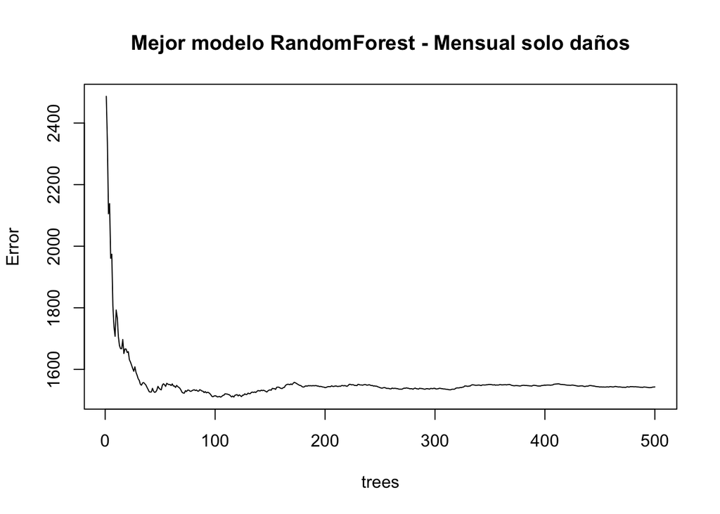

### 5.1.2 **Accidentes con Heridos**

El mejor modelo para la predicción mensual de accidentes con heridos se obtuvo analizando y ajustando los hiperparametros del RandomForest. En este caso se evaluaron diferentes combinaciones de mtry, nodesizes y sample_size.

En el siguiente [enlace](https://rpubs.com/Manulondo95/658271) se puede encontrar la evaluación de los tres modelos considerados y el tuning realizado al modelo de RandomForest. En el proceso de validación se obtuvieron las siguientes métricas de ajuste:

| Metrica | Resultados |
| --- | --- |
| RMSE Train | 38.01704 |
| Rsquared_Train | 0.9523667 |
| Rsquared_Test | 51.69021 |
| Rsquared_Test | 0.9465184 |
| Variación RMSE | 35.96% |

**Entrenamiento del modelo**

Se entrena el modelo con todas las observaciones que componen la base de datos de estudio:

```r
#### entrenamiento del modelo ####
set.seed(101)

mejorRandomforest2 <- randomForest(HERIDOS.R ~., data = mensual_heridos_train, mtry = 3,
                                  nodesize = 11, ntree = 500, sampe_size= 0.8,
                                  importance = TRUE)

mejorRandomforest2
```

```
##
## Call:
##  randomForest(formula = HERIDOS.R ~ ., data = mensual_heridos_train,      mtry = 3, nodesize = 11, ntree = 500, sampe_size = 0.8, importance = TRUE)
##                Type of random forest: regression
##                      Number of trees: 500
## No. of variables tried at each split: 3
##
##           Mean of squared residuals: 2958.147
##                     % Var explained: 89.84
```

**Predicciones**

Se realizan las predicciones para el año 2019:

```r
#### predicciones de test####
pred_randomForest2 <- predict(mejorRandomforest2, mensual_heridos_test)

# Adición de las predicciones al dataset de test
mensual_heridos_test <- cbind(mensual_heridos_test, pred_randomForest2)

#Guardamos resultados en csv
#write.csv(solo_danos_test, file="mensual_h_predicción.csv", row.names = FALSE)
```

**Resultado del bosque en función del número de arboles**

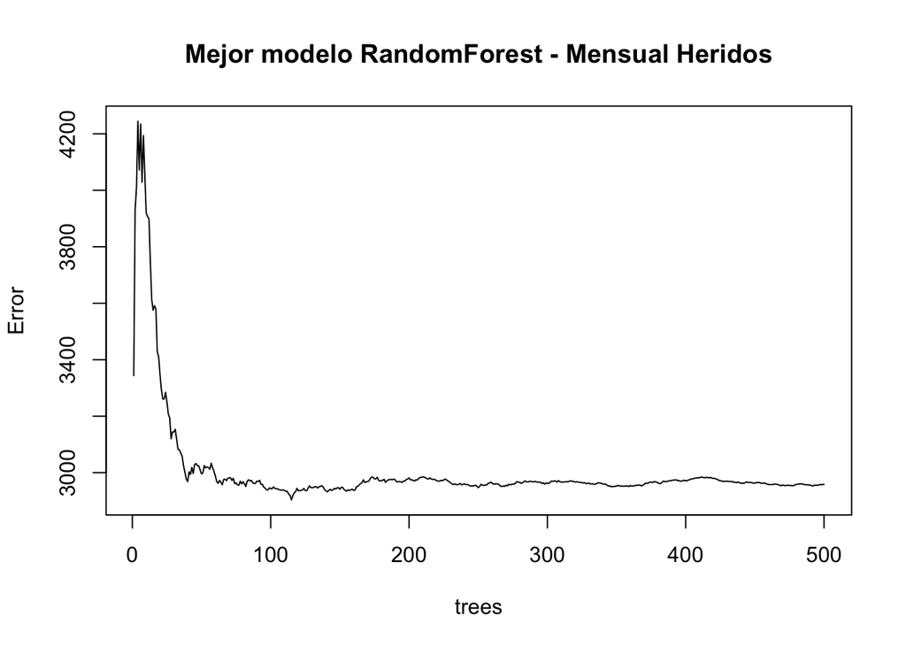

### 5.1.3 **Accidentes con Muertos**

El mejor modelo para la predicción mensual de accidentes con muertos se obtuvo analizando y ajustando los hiperparametros del RandomForest. En este caso se evaluaron diferentes combinaciones de mtry, nodesizes y sample_size.

En el siguiente [enlace](https://rpubs.com/Manulondo95/658327) se puede encontrar la evaluación de los tres modelos considerados y el tuning realizado al modelo de RandomForest. En el proceso de validación se obtuvieron las siguientes métricas de ajuste:

| Metrica | Resultados |
| --- | --- |
| RMSE Train | 1.467876 |
| Rsquared_Train | 0.6377918 |
| Rsquared_Test | 2.43624 |
| Rsquared_Test | 0.1949702 |
| Variación RMSE | 65.9% |

**Entrenamiento del modelo**

Se entrena el modelo con todas las observaciones que componen la base de datos de estudio:

```r
#### entrenamiento del modelo ####
set.seed(101)

set.seed(101)
mejorRandomforest3 <- randomForest(MUERTES.R ~., data = mensual_muertes_train, mtry = 3, nodesize = 11,
                                  ntree = 500, sample_size= 0.8, importance = TRUE)
mejorRandomforest3
```

```
##
## Call:
##  randomForest(formula = MUERTES.R ~ ., data = mensual_muertes_train,      mtry = 3, nodesize = 11, ntree = 500, sample_size = 0.8,      importance = TRUE)
##                Type of random forest: regression
##                      Number of trees: 500
## No. of variables tried at each split: 3
##
##           Mean of squared residuals: 4.066357
##                     % Var explained: 33.42
```

**Predicciones**

Se realizan las predicciones para el año 2019:

```r
#### predicciones de test####
pred_randomForest3 <- predict(mejorRandomforest3, mensual_muertes_test)

# Adición de las predicciones al dataset de test
mensual_muertes_test <- cbind(mensual_muertes_test, pred_randomForest3)

#Guardamos resultados en csv
#write.csv(solo_danos_test, file="mensual_m_predicción.csv", row.names = FALSE)
```

**Resultado del bosque en función del número de arboles**

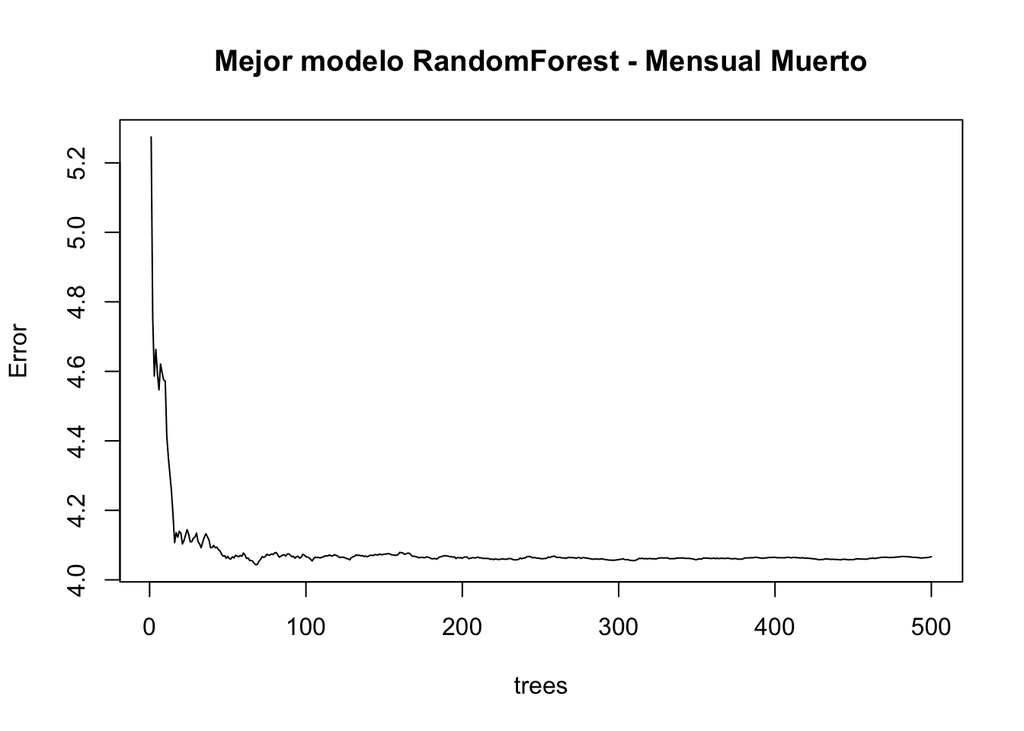

## 5.2 **Modelos Semanales**

### 5.2.1 **Accidentes con Solo Daños**

El mejor modelo para la predicción semanal de accidentes con solo daños, se obtuvo analizando los Hiperparametros del RandomForest. En este caso se evaluaron diferentes combinaciones de mtry, nodesizes y sample_size.

En el siguiente [enlace](https://rpubs.com/Manulondo95/658405) se puede encontrar la evaluación de los tres modelos considerados y el tuning realizado al modelo de RandomForest. En el proceso de validación se obtuvieron las siguientes métricas de ajuste:

| Metrica | Resultados |
| --- | --- |
| RMSE Train | 39.16793 |
| Rsquared_Train | 0.9386766 |
| Rsquared_Test | 47.72794 |
| Rsquared_Test | 0.9018913 |
| Variación RMSE | 21.8% |

**Entrenamiento del modelo**

Se entrena el modelo con todas las observaciones que componen la base de datos de estudio:

```r
#### entrenamiento del modelo ####
set.seed(101)
mejorRandomforest4 <- randomForest(SOLO_DANOS ~., data = semanal_solo_danos_train,
                                   mtry = 8, nodesize = 7, ntree = 500, sampe_size= 0.8,
                                   importance = TRUE)
mejorRandomforest4
```

```
##
## Call:
##  randomForest(formula = SOLO_DANOS ~ ., data = semanal_solo_danos_train,      mtry = 8, nodesize = 7, ntree = 500, sampe_size = 0.8, importance = TRUE)
##                Type of random forest: regression
##                      Number of trees: 500
## No. of variables tried at each split: 8
##
##           Mean of squared residuals: 2388.597
##                     % Var explained: 90.22
```

**Predicciones**

Se realizan las predicciones para el año 2019:

```r
#### predicciones de test####
pred_randomForest4 <- predict(mejorRandomforest4, semanal_solo_danos_test)

# Adición de las predicciones al dataset de test
semanal_solo_danos_test <- cbind(semanal_solo_danos_test, pred_randomForest4)

#Guardamos resultados en csv
#write.csv(solo_danos_test, file="mensual_sd_predicción.csv", row.names = FALSE)
```

**Resultado del bosque en función del número de arboles**

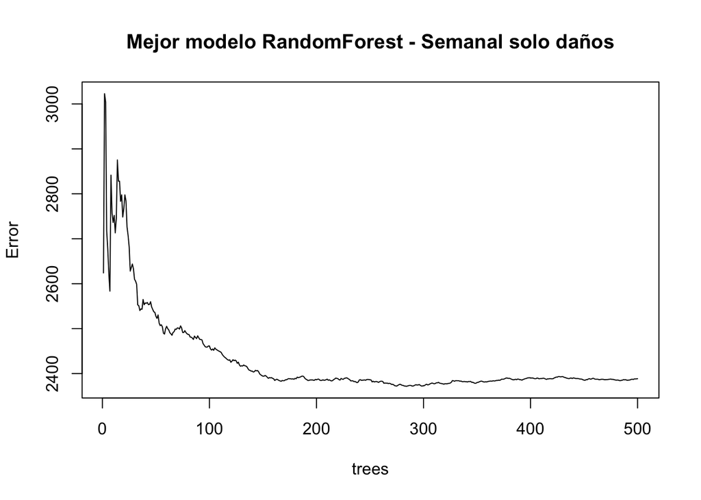

### 5.2.2 **Accidentes con Heridos**

El mejor modelo para la predicción semanal de accidentes con heridos, se obtuvo analizando los Hiperparametros del RandomForest. En este caso se evaluaron diferentes combinaciones de mtry, nodesizes y sample_size.

En el siguiente [enlace](https://rpubs.com/Manulondo95/658401) se puede encontrar la evaluación de los tres modelos considerados y el tuning realizado al modelo de RandomForest. En el proceso de validación se obtuvieron las siguientes métricas de ajuste:

| Metrica | Resultados |
| --- | --- |
| RMSE Train | 52.16871 |
| Rsquared_Train | 0.9199635 |
| Rsquared_Test | 67.58887 |
| Rsquared_Test | 0.8806061 |
| Variación RMSE | 29% |

**Entrenamiento del modelo**

Se entrena el modelo con todas las observaciones que componen la base de datos de estudio:

```r
#### entrenamiento del modelo ####
set.seed(101)
mejorRandomforest5 <- randomForest(HERIDOS ~., data = semanal_heridos_train,
                                   mtry = 9, nodesize = 29, ntree = 500,
                                   sampe_size= 0.8, importance = TRUE)
mejorRandomforest5
```

```
##
## Call:
##  randomForest(formula = HERIDOS ~ ., data = semanal_heridos_train,      mtry = 9, nodesize = 29, ntree = 500, sampe_size = 0.8, importance = TRUE)
##                Type of random forest: regression
##                      Number of trees: 500
## No. of variables tried at each split: 9
##
##           Mean of squared residuals: 4078.454
##                     % Var explained: 87.24
```

**Predicciones**

Se realizan las predicciones para el año 2019:

```r
#### predicciones de test####
pred_randomForest5 <- predict(mejorRandomforest5, semanal_heridos_test)

# Adición de las predicciones al dataset de test
semanal_heridos_test <- cbind(semanal_heridos_test, pred_randomForest5)

#Guardamos resultados en csv
#write.csv(solo_danos_test, file="mensual_sd_predicción.csv", row.names = FALSE)
```

**Resultado del bosque en función del número de arboles**

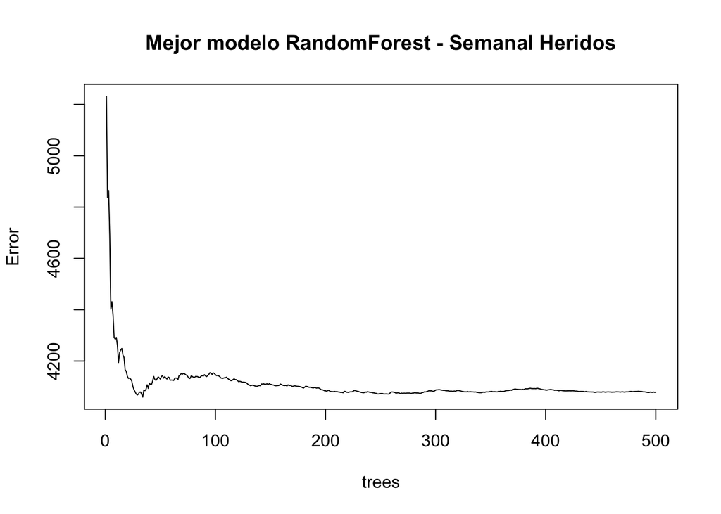

### 5.2.3 **Accidentes con Muertos**

El mejor modelo para la predicción semanal de accidentes con muertes, se obtuvo analizando los Hiperparametros del RandomForest. En este caso se evaluaron diferentes combinaciones de mtry, nodesizes y sample_size.

En el siguiente [enlace](https://rpubs.com/Manulondo95/658421) se puede encontrar la evaluación de los tres modelos considerados y el tuning realizado al modelo de RandomForest. En el proceso de validación se obtuvieron las siguientes métricas de ajuste:

| Metrica | Resultados |
| --- | --- |
| RMSE Train | 1.723351 |
| Rsquared_Train | 0.5197893 |
| Rsquared_Test | 2.931637 |
| Rsquared_Test | 0.2917401 |
| Variación RMSE | 70% |

**Entrenamiento del modelo**

Se entrena el modelo con todas las observaciones que componen la base de datos de estudio:

```r
#### entrenamiento del modelo ####
set.seed(101)
mejorRandomforest6 <- randomForest(MUERTES ~., data = semanal_muertes_train, mtry = 6,
                                  nodesize = 7, sampe_size = 0.8,
                                  ntree = 500, importance = TRUE)
mejorRandomforest6
```

```
##
## Call:
##  randomForest(formula = MUERTES ~ ., data = semanal_muertes_train,      mtry = 6, nodesize = 7, sampe_size = 0.8, ntree = 500, importance = TRUE)
##                Type of random forest: regression
##                      Number of trees: 500
## No. of variables tried at each split: 6
##
##           Mean of squared residuals: 4.659792
##                     % Var explained: 35.78
```

**Predicciones**

Se realizan las predicciones para el año 2019:

```r
#### predicciones de test####
pred_randomForest6 <- predict(mejorRandomforest6, semanal_muertes_test)

# Adición de las predicciones al dataset de test
semanal_muertes_test <- cbind(semanal_muertes_test, pred_randomForest6)

#Guardamos resultados en csv
#write.csv(solo_danos_test, file="mensual_sd_predicción.csv", row.names = FALSE)
```

**Resultado del bosque en función del número de arboles**

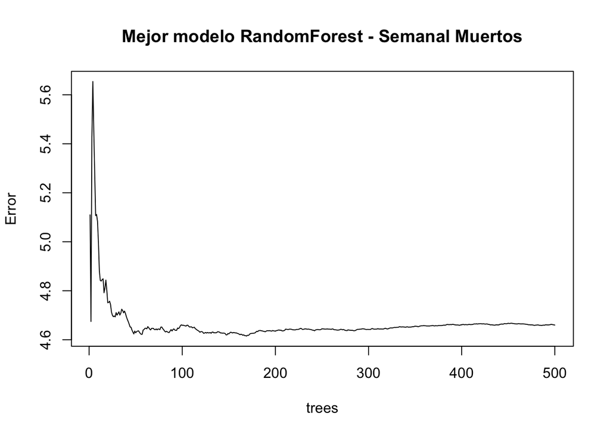

## 5.3 **Modelos Diarios**

### 5.3.1 **Accidentes con Solo Daños**

El mejor modelo para la predicción diaria de accidentes con solo daños, se obtuvo analizando los Hiperparametros del RandomForest. En este caso se evaluaron diferentes combinaciones de mtry, nodesizes y sample_size.

En el siguiente [enlace](https://rpubs.com/Manulondo95/658435) se puede encontrar la evaluación de los tres modelos considerados y el tuning realizado al modelo de RandomForest. En el proceso de validación se obtuvieron las siguientes métricas de ajuste:

| Metrica | Resultados |
| --- | --- |
| RMSE Train | 10.13616 |
| Rsquared_Train | 0.6372575 |
| Rsquared_Test | 10.86129 |
| Rsquared_Test | 0.5764182 |
| Variación RMSE | 7.2% |

**Entrenamiento del modelo**

Se entrena el modelo con todas las observaciones que componen la base de datos de estudio:

```r
#### entrenamiento del modelo ####
set.seed(101)

mejorRandomforest7 <- randomForest(SOLO_DANOS ~., data = diario_solo_danos_train,
                                   mtry = 8, nodesize = 11, ntree = 500,
                                   sampe_size= 0.8, importance = TRUE)
mejorRandomforest7
```

```
##
## Call:
##  randomForest(formula = SOLO_DANOS ~ ., data = diario_solo_danos_train,      mtry = 8, nodesize = 11, ntree = 500, sampe_size = 0.8, importance = TRUE)
##                Type of random forest: regression
##                      Number of trees: 500
## No. of variables tried at each split: 8
##
##           Mean of squared residuals: 108.0082
##                     % Var explained: 61.7
```

**Predicciones**

Se realizan las predicciones para el año 2019:

```r
#### predicciones de test####
pred_randomForest7 <- predict(mejorRandomforest7, diario_solo_danos_test)

# Adición de las predicciones al dataset de test
diario_solo_danos_test <- cbind(diario_solo_danos_test, pred_randomForest7)

#Guardamos resultados en csv
#write.csv(solo_danos_test, file="mensual_sd_predicción.csv", row.names = FALSE)
```

**Resultado del bosque en función del número de arboles**

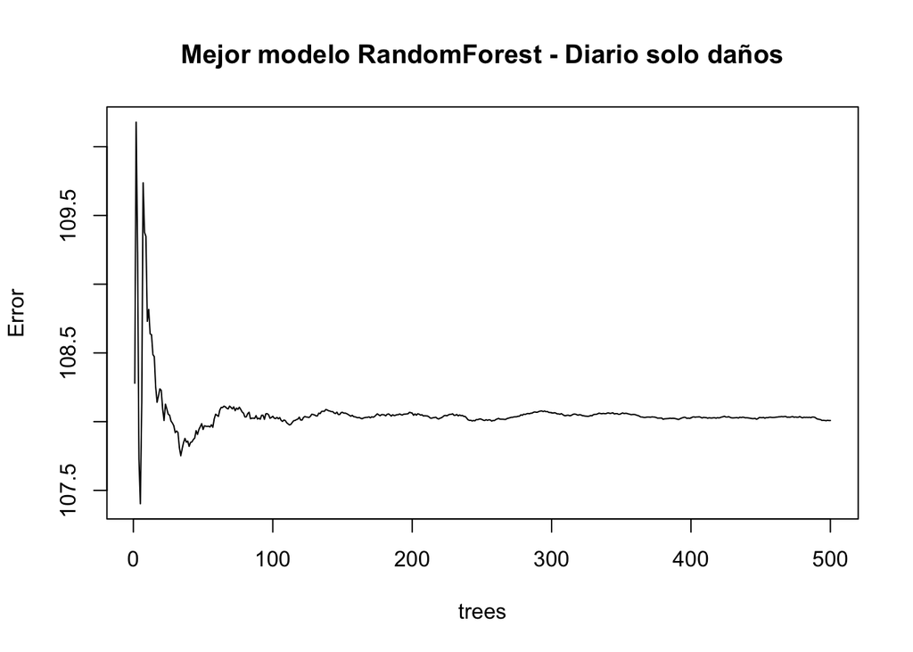

### 5.3.2 **Accidentes con Heridos**

El mejor modelo para la predicción diaria de accidentes con heridos, se obtuvo analizando los Hiperparametros del RandomForest. En este caso se evaluaron diferentes combinaciones de mtry, nodesizes y sample_size.

En el siguiente [enlace](https://rpubs.com/Manulondo95/658443) se puede encontrar la evaluación de los tres modelos considerados y el tuning realizado al modelo de RandomForest. En el proceso de validación se obtuvieron las siguientes métricas de ajuste:

| Metrica | Resultados |
| --- | --- |
| RMSE Train | 10.66488 |
| Rsquared_Train | 0.346224 |
| Rsquared_Test | 11.82162 |
| Rsquared_Test | 0.424438 |
| Variación RMSE | 10.8% |

**Entrenamiento del modelo**

Se entrena el modelo con todas las observaciones que componen la base de datos de estudio:

```r
#### entrenamiento del modelo ####
set.seed(101)

mejorRandomforest8 <- randomForest(HERIDOS ~., data = diario_heridos_train, mtry = 10,
                                  nodesize = 7, ntree = 500, sampe_size= 0.8,
                                  importance = TRUE)

mejorRandomforest8
```

```
##
## Call:
##  randomForest(formula = HERIDOS ~ ., data = diario_heridos_train,      mtry = 10, nodesize = 7, ntree = 500, sampe_size = 0.8, importance = TRUE)
##                Type of random forest: regression
##                      Number of trees: 500
## No. of variables tried at each split: 10
##
##           Mean of squared residuals: 118.5242
##                     % Var explained: 33.21
```

**Predicciones**

Se realizan las predicciones para el año 2019:

```r
#### predicciones de test####
pred_randomForest8 <- predict(mejorRandomforest8, diario_heridos_test)

# Adición de las predicciones al dataset de test
diario_heridos_test <- cbind(diario_heridos_test, pred_randomForest8)

#Guardamos resultados en csv
#write.csv(solo_danos_test, file="mensual_sd_predicción.csv", row.names = FALSE)
```

**Resultado del bosque en función del número de arboles**

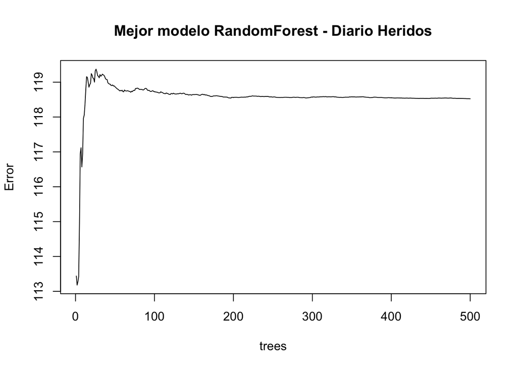

### 5.3.3 **Accidentes con Muertos**

El mejor modelo para la predicción diaria de accidentes con muertes, se obtuvo analizando los Hiperparametros del RandomForest. En este caso se evaluaron diferentes combinaciones de mtry, nodesizes y sample_size.

En el siguiente [enlace](http://rpubs.com/Manulondo95/658448) se puede encontrar la evaluación de los tres modelos considerados y el tuning realizado al modelo de RandomForest. En el proceso de validación se obtuvieron las siguientes métricas de ajuste:

[output not shown]

**Entrenamiento del modelo**

Se entrena el modelo con todas las observaciones que componen la base de datos de estudio:

```r
#### entrenamiento del modelo ####
set.seed(101)

mejorRandomforest9 <- randomForest(MUERTOS ~., data = diario_muertes_train, mtry = 14,
                                  nodesize = 11, ntree = 500, sample_size = 0.8,
                                  importance = TRUE)
mejorRandomforest9
```

[output not shown]

**Predicciones**

Se realizan las predicciones para el año 2019:

```r
#### predicciones de test####
pred_randomForest9 <- predict(mejorRandomforest9, diario_muertes_test)

# Adición de las predicciones al dataset de test
diario_muertes_test<- cbind(diario_muertes_test, pred_randomForest9)

#Guardamos resultados en csv
#write.csv(solo_danos_test, file="mensual_sd_predicción.csv", row.names = FALSE)
```

**Resultado del bosque en función del número de arboles**

[figure not shown]

# 6 **Agrupamiento de los barrios por nivel de accidentalidad**

Para el presente trabajo se realizó el modelamiento de dos tipos de agrupamiento:

1. El primer agrupamiento considera múltiples variables con el fin de calificar zonas según el riesgo de accidentalidad vial. Las variables consideradas fueron: El promedio de la accidentalidad, los dias de la semana, la cantidad acumulada de accidentes mensuales, fines de semana y días laborales. También se incluyo la gravedad y el tipo de accidentes.

Aqui se puede encontrar el desarrollo del primer agrupamiento [Agrupamiento Multivariable](https://rpubs.com/wajovel/acciodentesmed)

Los resultados de este modelamiento pueden verse en el aplicativo [sinfomovil](https://william-jovel.shinyapps.io/Accidentes/) en la pestaña: *“Cluster multivariable”*

También se incluyo un cluster jerarquico por comunas, pues da mayor comprensión visual respecto a la simulitud de zonas con respecto a su nivel de accidentalidad. Este cluster jerarquico también se encuentra en el aplicativo [sinfomovil](https://william-jovel.shinyapps.io/Accidentes/) en la pestaña: *“Dendograma”*

2. En el segundo agrupamiento se consideraron también diferentes variables, pero a diferencia del primero, estas variables hacen parte de un clustering específico según su gravedad. Las variables consideradas fueron: cantidad de accidentes en cada barrio, proporción de muertos / heridos / atropellos en los accidentes de cada barrio según correrponda.

Aqui se puede encontrar el desarrollo del primer agrupamiento [Agrupamiento Univariable](https://rpubs.com/wajovel/Clustacc2)

Los resultados de este modelamiento pueden verse en el aplicativo [sinfomovil](https://william-jovel.shinyapps.io/Accidentes/) en la pestaña: *“Cluster Univariable”*

# 7 **Conclusiones**

# 8 **Comentarios Adicionales**

- El trabajo desarrollado permitió aplicar diferentes técnicas de modelado para estimar la accidentalidad en Medellín a partir de los datos históricos disponibles, siendo éste un ejercicio responsable y acorde a las exigencias del mundo donde se busca solucionar problemas reales en escenarios de mucha incertidumbre, donde se hace difícil encontrar relaciones entre las variables y donde deben de intentarse una y otra vez alternativas para satisfacer los requisitos de los problemas de minería de datos.
- Para el equipo representó un gran aprendizaje ahondar en las técnicas de clustering, en cómo asociar modelos que contengan múltiples variables para agrupar por similitud las comunas y barrios de Medellín y explorar a su vez las bondades de diseñar un aplicativo en RShiny -en tiempo récord- que fuera dinámico, práctico y usable para el cliente final.
- Estimar modelos que tuvieran un R2 superior a 70% fue un propósito desde el principio y para ello se construyeron n mil variables y sus interacciones con el fin de mejorar los métricos de éxito, utilizando en ese sentido varios métodos de regresión. Consideramos que como ejercicio sirvió mucho para salirnos de la zona de confort y pensar en esas variables que pueden influir potencialmente en la variable dependiente haciendo múltiples ensayos

# 9 **Referencias**

Orellana Alvear, J. (2018). Arboles de decision y Random Forest. Retrieved September 08, 2020, from https://bookdown.org/content/2031/ensambladores-random-forest-parte-ii.html#ejemplo-de-regresion-tuning

# 10 **Enlaces de interes**

- Repositorio de Github: https://github.com/Manuela9595/Prediccion_Accidentalidad_medellin
- Video de presentación: https://www.youtube.com/watch?v=wa_Dwvy1Krc&feature=youtu.be